# Research Question 2: How can we improve the missing data imputation?

Kirsten van Kessel

2024-04-11

#### Setup

We read in the data, scale the indicators so the mean of all pupils is 0 (instead of over only the sample). We then select only the complete cases to work with.

```r
# load libraries
library(haven)
library(dplyr)
library(mice)
library(missMethods)
library(ggplot2)

# load data
data <- read_sav("../data/CY07_MSU_STU_QQQ.sav")

# select subset variables
data <- data %>% select(CNT, CNTSTUID, LANGTEST_QQQ, ST011Q01TA:ST011Q16NA, ST011D17TA:ST011D19TA, ST012Q01TA:ST012Q09NA, ST013Q01TA, HOMEPOS, HISEI, PAREDINT, ESCS)
head(data)

# set seed
set.seed(679)

# scale indicators
data$HISEI <- scale(data$HISEI)
data$HOMEPOS <- scale(data$HOMEPOS)
data$PAREDINT <- scale(data$PAREDINT)

# complete data
data_complete <- data %>%
  select(CNT, CNTSTUID, HOMEPOS, HISEI, PAREDINT, ESCS) %>% # only select variables
  filter(complete.cases(HOMEPOS, HISEI, PAREDINT)) # only rows without missing values
head(data_complete)
```

#### Inspect missingness

We inspect what percentage of the data is missing.

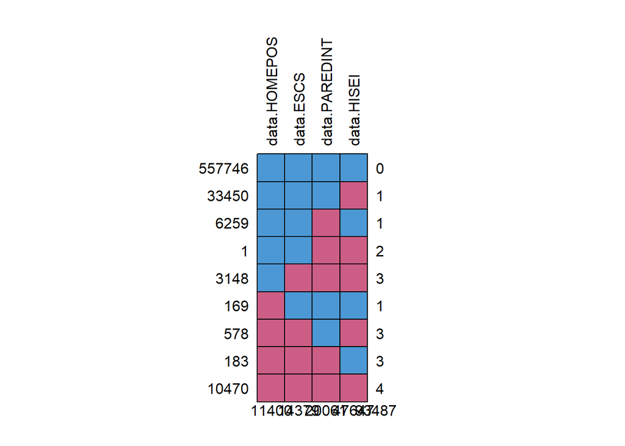

```
##        data.HOMEPOS data.ESCS data.PAREDINT data.HISEI
## 557746            1         1             1          1     0
## 33450             1         1             1          0     1
## 6259              1         1             0          1     1
## 1                 1         1             0          0     2
## 3148              1         0             0          0     3
## 169               0         1             1          1     1
## 578               0         0             1          0     3
## 183               0         0             0          1     3
## 10470             0         0             0          0     4
##               11400     14379         20061      47647 93487
```

```r
# make subset of indicators
data_indicators <- data %>% select(HOMEPOS, HISEI, PAREDINT)

# make a plot of the missingness
md.pattern(data.frame(data$HOMEPOS, data$HISEI, data$PAREDINT, data$ESCS),
           rotate.names = TRUE)
```

```r
# missing all three variables
10470 / 612004 * 100 # 1.71%
```

```
## [1] 1.710773
```

```r
# missing two variables
(183+578+3149) / 612004 * 100 # 0.64%
```

```
## [1] 0.6388847
```

```r
# missing one variable
(33450+6259+169) / 612004 * 100 # 6.52%
```

```
## [1] 6.51597
```

```r
# complete
557746 / 612004 * 100 # 91.13%
```

```
## [1] 91.13437
```

```r
# percentage missing values total
sum(is.na(data_indicators)) / (nrow(data_indicators)*ncol(data_indicators)) * 100 # 4.31%
```

```
## [1] 4.308686
```

#### Function for MSE

MSE is the mean squared error: a measure for how well predicted data matches the observed data. We use this to compare the ‘known’ ESCS with the ESCS computed after each imputation method.

```r
mse <- function(obs, pred){
  mse <- mean((obs - pred)^2)
  return(mse)
}
```

#### Method 1: Do not impute

In this method, we do not impute missing values. First, a random sample of 50,000 pupils is made. Then, 4.31% of the indicator values is randomly deleted to create holes in the dataframe. This is because in the original data, 4.31% of values on the indicators is missing. Then, the mean is taken to compute ESCS.

Within this method there are two methods to take the mean of the indicators: original and full.

In the method we call ‘original’, the mean gets taken including the missing values. This means that when one value is missing, the mean also is missing. This is called ‘original’, because this is the way PISA takes the mean of the three indicators.

In the method we call ‘full’, the mean of the three indicators is taken, ignoring any missing values. So, if there is one missing value, the ESCS value is the mean of the two not missing values. If there are two missing values, the ESCS value is the same as the one not missing value.

To compute the MSE, we need a full column. Otherwise an error is given. Therefore, only complete cases are used. This leads to a lower MSE for the ‘original’ method, as less cases are used and the ones used are complete.

```r
# set seed
set.seed(679)

# storage to save the mse
mse_notimputed_full <- c(rep(0,10))
mse_notimputed_orig <- c(rep(0,10))

for(i in 1:10) {
  # take a random sample of 4800 complete cases
  data_sample <- data_complete[sample(nrow(data_complete), size = 50000),]

  # make 4.31% of indicator values missing
  data_missing <- data_sample %>% select(HOMEPOS, HISEI, PAREDINT) %>% delete_MCAR(0.0431)

  # add country, ID and ESCS back to dataframe
  data_missing <- data.frame(data_missing, CNT = data_sample$CNT,
                             CNTSTUID = data_sample$CNTSTUID, ESCS = data_sample$ESCS)

  # calculate ESCS
 data_missing$ESCS_notimputed_full <- apply(cbind(data_missing$HOMEPOS, data_missing$PAREDINT,
                                                  data_missing$HISEI), 1, mean, na.rm = TRUE)

 data_missing$ESCS_notimputed_orig <- apply(cbind(data_missing$HOMEPOS, data_missing$PAREDINT,
                                                  data_missing$HISEI), 1, mean, na.rm = FALSE)

  # compare calculated ESCS to true ESCS
  mse_notimputed_full[i] <-
    mse(data_missing$ESCS[complete.cases(data_missing$ESCS_notimputed_full)],
      data_missing$ESCS_notimputed_full[complete.cases(data_missing$ESCS_notimputed_full)])

  mse_notimputed_orig[i] <-
    mse(data_missing$ESCS[complete.cases(data_missing$ESCS_notimputed_orig)],
        data_missing$ESCS_notimputed_orig[complete.cases(data_missing$ESCS_notimputed_orig)])
}

# inspect mse of not imputed ESCS deleting missing values
mse_notimputed_full
```

```
##  [1] 0.1913850 0.1907767 0.1910217 0.1895736 0.1909922 0.1897231 0.1904332
##  [8] 0.1934365 0.1890959 0.1902123
```

```r
mean(mse_notimputed_full)
```

```
## [1] 0.190665
```

```r
sd(mse_notimputed_full)
```

```
## [1] 0.001213129
```

```r
# inspect mse of not imputed ESCS not deleting missing values
mse_notimputed_orig
```

```
##  [1] 0.1785565 0.1786253 0.1782071 0.1757468 0.1794320 0.1774970 0.1775894
##  [8] 0.1793307 0.1752811 0.1776256
```

```r
mean(mse_notimputed_orig)
```

```
## [1] 0.1777891
```

```r
sd(mse_notimputed_orig)
```

```
## [1] 0.001380461
```

#### Method 2: Stochastic regression imputation

In this method, stochastic regression imputation is used exactly how PISA used it: When one indicator is missing, the value is imputed. When two or more indicators are missing, the value cannot be imputed. Again, a random sample of 50,000 pupils with 4.31 of values randomly missing is used.

Again, the two different methods for calculating the mean are used and compared.

```r
# set seed
set.seed(679)

# storage to save the mse
mse_stoch_full <- c(rep(0,10))
mse_stoch_orig <- c(rep(0,10))

for(i in 1:10) {
  # take a random sample of 4800 complete cases
  data_sample <- data_complete[sample(nrow(data_complete), size = 50000),]

  # make 4.31% of indicator values missing
  data_missing <- data_sample %>% select(HOMEPOS, HISEI, PAREDINT) %>% delete_MCAR(0.0431)

  # add country, ID and ESCS back to dataframe
  data_missing <- data.frame(data_missing, CNT = data_sample$CNT,
                             CNTSTUID = data_sample$CNTSTUID, ESCS = data_sample$ESCS)

  # impute missing values indicators

  # make a list of countries
  country_list <- unique(data_missing$CNT)

  # empty data_all
  data_all <- data.frame()

  # for each country
  for(country in country_list){

  data_ind <- data_missing %>% filter(CNT == country)

  # HOMEPOS
  model_home <- lm(data = data_ind, HOMEPOS ~ PAREDINT + HISEI)
  summary(model_home)

  data_im <- data_ind %>% mutate(homepos_im = case_when(
    is.na(HOMEPOS) ~ model_home$coefficients[1] + model_home$coefficients[2]*PAREDINT +
    model_home$coefficients[3]*HISEI + rnorm(1, 0, summary(model_home)$sigma),
    TRUE ~ HOMEPOS))

  # PAREDINT
  model_paredint <- lm(data = data_ind, PAREDINT ~ HOMEPOS + HISEI)
  summary(model_paredint)

  data_im <- data_im %>% mutate(paredint_im = case_when(
    is.na(PAREDINT) ~ model_paredint$coefficients[1]
    + model_paredint$coefficients[2]*HOMEPOS + model_paredint$coefficients[3]*HISEI +
    rnorm(1,0, summary(model_paredint)$sigma),
    TRUE ~ PAREDINT))

  # HISEI
  model_hisei <- lm(data = data_ind, HISEI ~ PAREDINT + HOMEPOS)
  summary(model_hisei)

  data_im <- data_im %>% mutate(hisei_im = case_when(
    is.na(HISEI) ~ model_hisei$coefficients[1] + model_hisei$coefficients[2]*PAREDINT +
    model_hisei$coefficients[3]*HOMEPOS + rnorm(1, 0, summary(model_hisei)$sigma),
    TRUE ~ HISEI))

  data_all <- rbind(data_all, data_im)
  }

  # calculate ESCS with imputed values
  data_missing$ESCS_stochimputed_full <- apply(cbind(data_all$homepos_im,
    data_all$paredint_im, data_all$hisei_im), 1, mean, na.rm = TRUE)

  data_missing$ESCS_stochimputed_original <- apply(cbind(data_all$homepos_im,
    data_all$paredint_im, data_all$hisei_im), 1, mean, na.rm = FALSE)

  # calculate MSE full
  mse_stoch_full[i] <- mse(data_missing$ESCS[complete.cases(
    data_missing$ESCS_stochimputed_full)],
    data_missing$ESCS_stochimputed_full[complete.cases(data_missing$ESCS_stochimputed_full)])

  # calculate MSE original
  mse_stoch_orig[i] <- mse(data_missing$ESCS[complete.cases(
    data_missing$ESCS_stochimputed_original)],
    data_missing$ESCS_stochimputed_original[complete.cases(
    data_missing$ESCS_stochimputed_original)])
}

# inspect mse of stochastic regression imputed ESCS deleting missing values
mse_stoch_full
```

```
##  [1] 1.931350 1.959704 1.946790 1.933176 1.940918 1.922046 1.914797 1.931189
##  [9] 1.923445 1.942341
```

```r
mean(mse_stoch_full)
```

```
## [1] 1.934576
```

```r
sd(mse_stoch_full)
```

```
## [1] 0.01323738
```

```r
# inspect mse of stochastic regression imputed ESCS not deleting missing values
mse_stoch_orig
```

```
##  [1] 1.929251 1.958041 1.945117 1.931394 1.939396 1.922015 1.912774 1.929529
##  [9] 1.920932 1.941369
```

```r
mean(mse_stoch_orig)
```

```
## [1] 1.932982
```

```r
sd(mse_stoch_orig)
```

```
## [1] 0.01328703
```

#### Method 3: Multiple imputation

The last method used a simple multiple imputation method to impute the missing values.

Again, a random sample of 50,000 pupils with 4.31 of values randomly missing is used.

```r
# set seed
set.seed(679)

# storage to save the mse
mse_mice <- c(rep(0,10))

for(i in 1:10) {
  # take a random sample of 4800 complete cases
  data_sample <- data_complete[sample(nrow(data_complete), size = 50000),]

  # make 4.31% of indicator values missing
  data_missing <- data_sample %>% select(HOMEPOS, HISEI, PAREDINT) %>% delete_MCAR(0.0431)

  # add country, ID back to dataframe
  data_missing <- data.frame(data_missing, CNT = data_sample$CNT,
                             CNTSTUID = data_sample$CNTSTUID, ESCS = data_sample$ESCS)

  # impute missing values indicators
  imp <- mice(data_missing, maxit = 5, m = 5, method = "cart", seed = 679)

  # make completed dataset
  completed <- complete(imp)

  # calculate ESCS with imputed values
  data_missing$ESCS_multimputed <- apply(cbind(completed$HOMEPOS, completed$PAREDINT,
                                               completed$HISEI), 1, mean, na.rm = TRUE)

  # calculate MSE
  mse_mice[i] <- mse(data_missing$ESCS, data_missing$ESCS_multimputed)
}
```

```r
# inspect mse of multiple imputed ESCS
mse_mice
```

```
##  [1] 0.1793856 0.1772895 0.1784346 0.1778366 0.1765234 0.1780158 0.1761362
##  [8] 0.1765954 0.1776389 0.1764675
```

```r
mean(mse_mice)
```

```
## [1] 0.1774323
```

```r
sd(mse_mice)
```

```
## [1] 0.001028715
```

#### Compare MSE

Make a table and figure to compare MSE between methods.

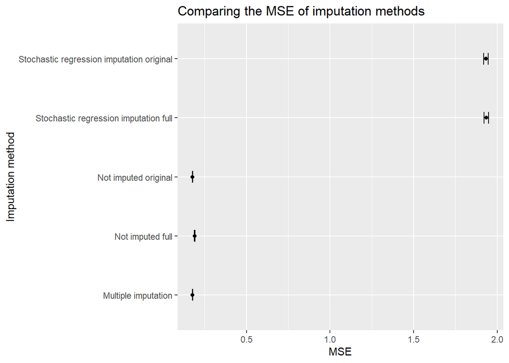

```r
method <- c("Not imputed full",
            "Not imputed original",
            "Stochastic regression imputation full",
            "Stochastic regression imputation original",
            "Multiple imputation")

mean <- c(mean(mse_notimputed_full),
          mean(mse_notimputed_orig),
          mean(mse_stoch_full),
          mean(mse_stoch_orig),
          mean(mse_mice))

sd <- c(sd(mse_notimputed_full),
        sd(mse_notimputed_orig),
        sd(mse_stoch_full),
        sd(mse_stoch_orig),
        sd(mse_mice))

MSE <- data.frame(method, mean, sd)

ggplot(MSE, aes(x=mean, y=method)) +
  geom_point() +
  ggtitle("Comparing the MSE of imputation methods") +
  xlab("MSE") +
  ylab("Imputation method") +
  geom_errorbar(aes(xmin=mean-sd, xmax=mean+sd), width=.2)
```